# Group 10

Tam Nguyen & Uyen Tran

2023-10-30

```r
#import data
setwd("C:/Users/phuon/Downloads")

amazon.df <- read_csv("sample1amazon.csv")
```

```
## ──────────────────────────────────────────────────────── Delimiter: "," chr
## (12): id, name, asins, brand, categories, keys, manufacturer, reviews.d... dbl
## (3): ...1, reviews.numHelpful, reviews.rating lgl (5): reviews.didPurchase,
## reviews.doRecommend, reviews.id, reviews.use... dttm (2): reviews.date,
## reviews.dateAdded
```

```r
head(amazon.df)
```

```
## # A tibble: 6 × 22
##    ...1 id                   name      asins brand categories keys  manufacturer
##   <dbl> <chr>                <chr>     <chr> <chr> <chr>      <chr> <chr>
## 1     1 AVpfl8cLLJeJML43AE3S "Echo (W… B00L… Amaz… Stereos,R… echo… Amazon
## 2     2 AVpfl8cLLJeJML43AE3S "Amazon … B00L… Amaz… Stereos,R… echo… Amazon
## 3     3 AV1YnRtnglJLPUi8IJmV "Amazon … B00O… Amaz… Walmart f… amaz… Amazon
## 4     4 AVpfl8cLLJeJML43AE3S "Echo (W… B00L… Amaz… Stereos,R… echo… Amazon
## 5     5 AVpfl8cLLJeJML43AE3S  <NA>     B00L… Amaz… Stereos,R… echo… Amazon
## 6     6 AVphgVaX1cnluZ0-DR74 "Fire Ta… B018… Amaz… Fire Tabl… fire… Amazon
## # ℹ 14 more variables: reviews.date <dttm>, reviews.dateAdded <dttm>,
## #   reviews.dateSeen <chr>, reviews.didPurchase <lgl>,
## #   reviews.doRecommend <lgl>, reviews.id <lgl>, reviews.numHelpful <dbl>,
## #   reviews.rating <dbl>, reviews.sourceURLs <chr>, reviews.text <chr>,
## #   reviews.title <chr>, reviews.userCity <lgl>, reviews.userProvince <lgl>,
## #   reviews.username <chr>
```

### **Looking at the data**

```r
skimr::skim(amazon.df)
```

Data summary

| Name | amazon.df |
| --- | --- |
| Number of rows | 25000 |
| Number of columns | 22 |
| _______________________ |  |
| Column type frequency: |  |
| character | 12 |
| logical | 5 |
| numeric | 3 |
| POSIXct | 2 |
| ________________________ |  |
| Group variables | None |

**Variable type: character**

| skim_variable | n_missing | complete_rate | min | max | empty | n_unique | whitespace |
| --- | --- | --- | --- | --- | --- | --- | --- |
| id | 0 | 1.0 | 20 | 20 | 0 | 42 | 0 |
| name | 4875 | 0.8 | 33 | 207 | 0 | 44 | 0 |
| asins | 2 | 1.0 | 10 | 21 | 0 | 41 | 0 |
| brand | 0 | 1.0 | 6 | 28 | 0 | 6 | 0 |
| categories | 0 | 1.0 | 26 | 725 | 0 | 41 | 0 |
| keys | 0 | 1.0 | 27 | 2328 | 0 | 42 | 0 |
| manufacturer | 0 | 1.0 | 6 | 28 | 0 | 2 | 0 |
| reviews.dateSeen | 0 | 1.0 | 20 | 1124 | 0 | 3561 | 0 |
| reviews.sourceURLs | 0 | 1.0 | 47 | 7786 | 0 | 10675 | 0 |
| reviews.text | 1 | 1.0 | 3 | 8351 | 0 | 24999 | 0 |
| reviews.title | 3 | 1.0 | 1 | 197 | 0 | 14705 | 0 |
| reviews.username | 2 | 1.0 | 1 | 25 | 0 | 19977 | 0 |

**Variable type: logical**

| skim_variable | n_missing | complete_rate | mean | count |
| --- | --- | --- | --- | --- |
| reviews.didPurchase | 25000 | 0.00 | NaN | : |
| reviews.doRecommend | 424 | 0.98 | 0.96 | TRU: 23555, FAL: 1021 |
| reviews.id | 25000 | 0.00 | NaN | : |
| reviews.userCity | 25000 | 0.00 | NaN | : |
| reviews.userProvince | 25000 | 0.00 | NaN | : |

**Variable type: numeric**

| skim_variable | n_missing | complete_rate | mean | sd | p0 | p25 | p50 | p75 | p100 | hist |
| --- | --- | --- | --- | --- | --- | --- | --- | --- | --- | --- |
| …1 | 0 | 1.00 | 12500.50 | 7217.02 | 1 | 6250.75 | 12500.5 | 18750.25 | 25000 | ▇▇▇▇▇ |
| reviews.numHelpful | 383 | 0.98 | 0.65 | 14.40 | 0 | 0.00 | 0.0 | 0.00 | 814 | ▇▁▁▁▁ |
| reviews.rating | 24 | 1.00 | 4.58 | 0.74 | 1 | 4.00 | 5.0 | 5.00 | 5 | ▁▁▁▃▇ |

**Variable type: POSIXct**

| skim_variable | n_missing | complete_rate | min | max | median | n_unique |
| --- | --- | --- | --- | --- | --- | --- |
| reviews.date | 31 | 1.00 | 2010-07-09 00:00:00 | 2018-04-18 00:00:00 | 2016-12-23 00:00:00 | 986 |
| reviews.dateAdded | 7633 | 0.69 | 2016-10-15 11:10:42 | 2017-12-11 02:05:37 | 2017-05-21 06:01:14 | 1917 |

### **Summary Missing Value**

```r
table.missing<-data.frame(miss.val=sapply(amazon.df, function(x)
  sum(length(which(is.na(x))))))
table.missing%>%kable(caption = "Number of missing values")%>%kableExtra::kable_styling(bootstrap_options = "striped")
```

Number of missing values

|  | miss.val |
| --- | --- |
| …1 | 0 |
| id | 0 |
| name | 4875 |
| asins | 2 |
| brand | 0 |
| categories | 0 |
| keys | 0 |
| manufacturer | 0 |
| reviews.date | 31 |
| reviews.dateAdded | 7633 |
| reviews.dateSeen | 0 |
| reviews.didPurchase | 25000 |
| reviews.doRecommend | 424 |
| reviews.id | 25000 |
| reviews.numHelpful | 383 |
| reviews.rating | 24 |
| reviews.sourceURLs | 0 |
| reviews.text | 1 |
| reviews.title | 3 |
| reviews.userCity | 25000 |
| reviews.userProvince | 25000 |
| reviews.username | 2 |

### **Understanding data by visualization**

**Distribution plot for numerical variable**

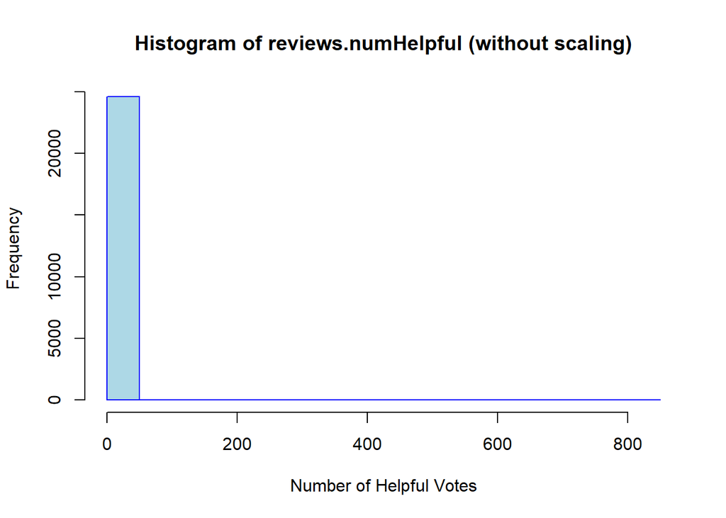

```r
# Histogram of "reviews.numHelpful"
hst1 <- hist(amazon.df$reviews.numHelpful,
     main = "Histogram of reviews.numHelpful (without scaling)",
     xlab = "Number of Helpful Votes",
     ylab = "Frequency",
     col = "lightblue",
     border = "blue")
```

```r
hst1
```

```
## $breaks
##  [1]   0  50 100 150 200 250 300 350 400 450 500 550 600 650 700 750 800 850
##
## $counts
##  [1] 24579    11     7     2     3     3     1     2     2     0     0     0
## [13]     1     1     3     1     1
##
## $density
##  [1] 1.996913e-02 8.936914e-06 5.687127e-06 1.624893e-06 2.437340e-06
##  [6] 2.437340e-06 8.124467e-07 1.624893e-06 1.624893e-06 0.000000e+00
## [11] 0.000000e+00 0.000000e+00 8.124467e-07 8.124467e-07 2.437340e-06
## [16] 8.124467e-07 8.124467e-07
##
## $mids
##  [1]  25  75 125 175 225 275 325 375 425 475 525 575 625 675 725 775 825
##
## $xname
## [1] "amazon.df$reviews.numHelpful"
##
## $equidist
## [1] TRUE
##
## attr(,"class")
## [1] "histogram"
```

The distribution of reviews.numHelpful is extremely skewed, which requires logarithmic scaling.

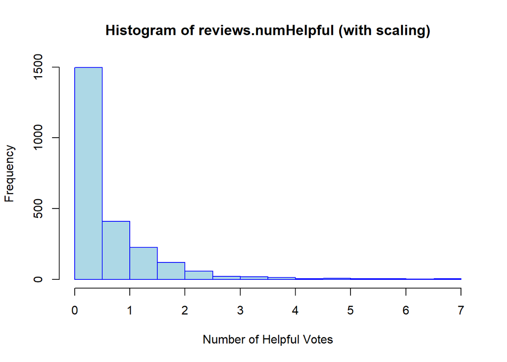

```r
# Histogram of "reviews.numHelpful"  after scaling
hst2 <- hist(log(amazon.df$reviews.numHelpful),
     main = "Histogram of reviews.numHelpful (with scaling)",
     xlab = "Number of Helpful Votes",
     ylab = "Frequency",
     col = "lightblue",
     border = "blue")
```

```r
hst2
```

```
## $breaks
##  [1] 0.0 0.5 1.0 1.5 2.0 2.5 3.0 3.5 4.0 4.5 5.0 5.5 6.0 6.5 7.0
##
## $counts
##  [1] 1495  410  227  121   60   21   20   14    6    9    5    6    4    5
##
## $density
##  [1] 1.244277986 0.341240117 0.188930504 0.100707449 0.049937578 0.017478152
##  [7] 0.016645859 0.011652102 0.004993758 0.007490637 0.004161465 0.004993758
## [13] 0.003329172 0.004161465
##
## $mids
##  [1] 0.25 0.75 1.25 1.75 2.25 2.75 3.25 3.75 4.25 4.75 5.25 5.75 6.25 6.75
##
## $xname
## [1] "log(amazon.df$reviews.numHelpful)"
##
## $equidist
## [1] TRUE
##
## attr(,"class")
## [1] "histogram"
```

**Distribution for categorical variables**

```r
# Distribution of "Brand"
# frequency table
tbl <- table(amazon.df$brand)
# compute the percentage of each category
round(tbl / nrow(amazon.df), 2)
```

```
##
##                       Amazon                Amazon Coco T
##                         0.83                         0.00
## Amazon Digital Services Inc.                  Amazon Echo
##                         0.00                         0.02
##                  Amazon Fire               Amazon Fire Tv
##                         0.01                         0.15
```

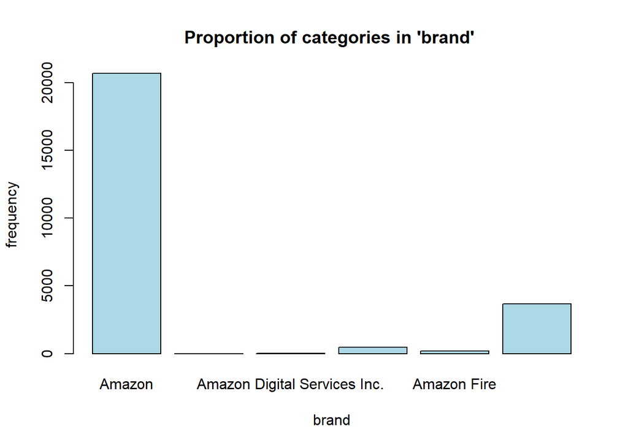

```r
# Bar chart on the proportion of each category in brand
barplot(tbl,
        xlab = "brand",
        ylab = "frequency",
        main = "Proportion of categories in 'brand' ",
        col = "lightblue")
```

```r
# Distribution of "manufacturer"
tbl1 <- table(amazon.df$manufacturer)
round(tbl1 / nrow(amazon.df),2)
```

```
##
##                       Amazon Amazon Digital Services, Inc
##                            1                            0
```

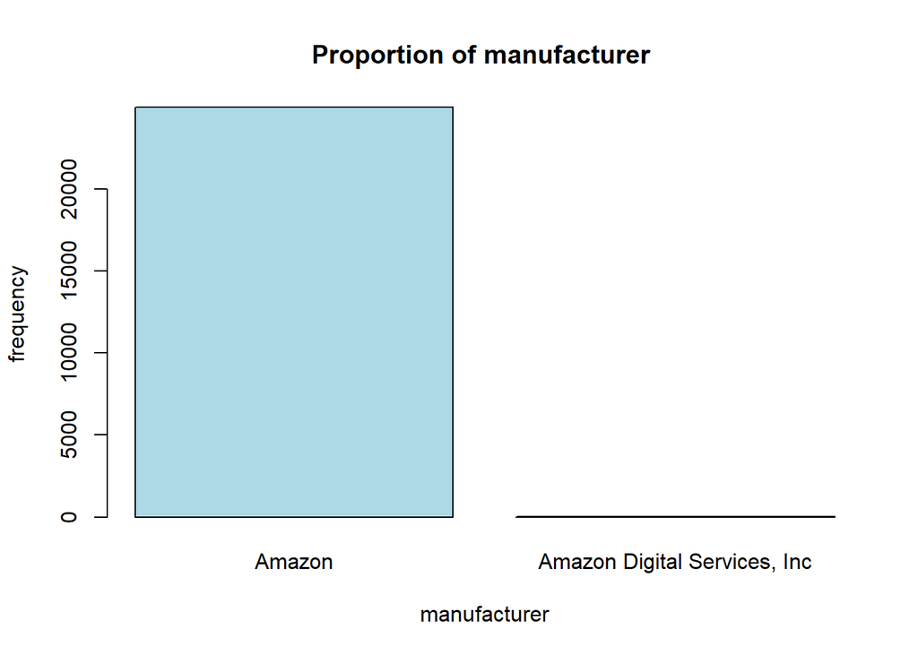

```r
# bar chart of frequency for manufacturer
barplot(tbl1,
        xlab = "manufacturer",
        ylab = "frequency",
        main = "Proportion of manufacturer ",
        col = "lightblue")
```

```r
# Distribution of "Reviews Rating"
tbl2 <- table(factor(amazon.df$reviews.rating))
round(tbl2 / nrow(amazon.df),2)
```

```
##
##    1    2    3    4    5
## 0.01 0.01 0.04 0.25 0.69
```

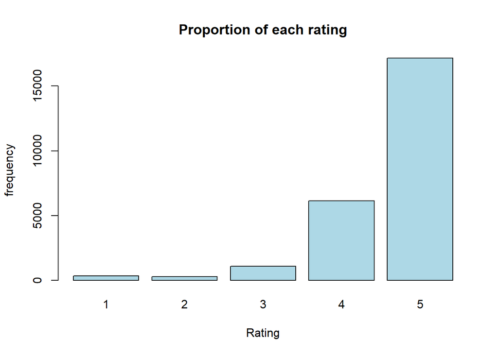

```r
# bar chart of frequency for Reviews Rating
barplot(tbl2,
        xlab = "Rating",
        ylab = "frequency",
        main = "Proportion of each rating",
        col = "lightblue")
```

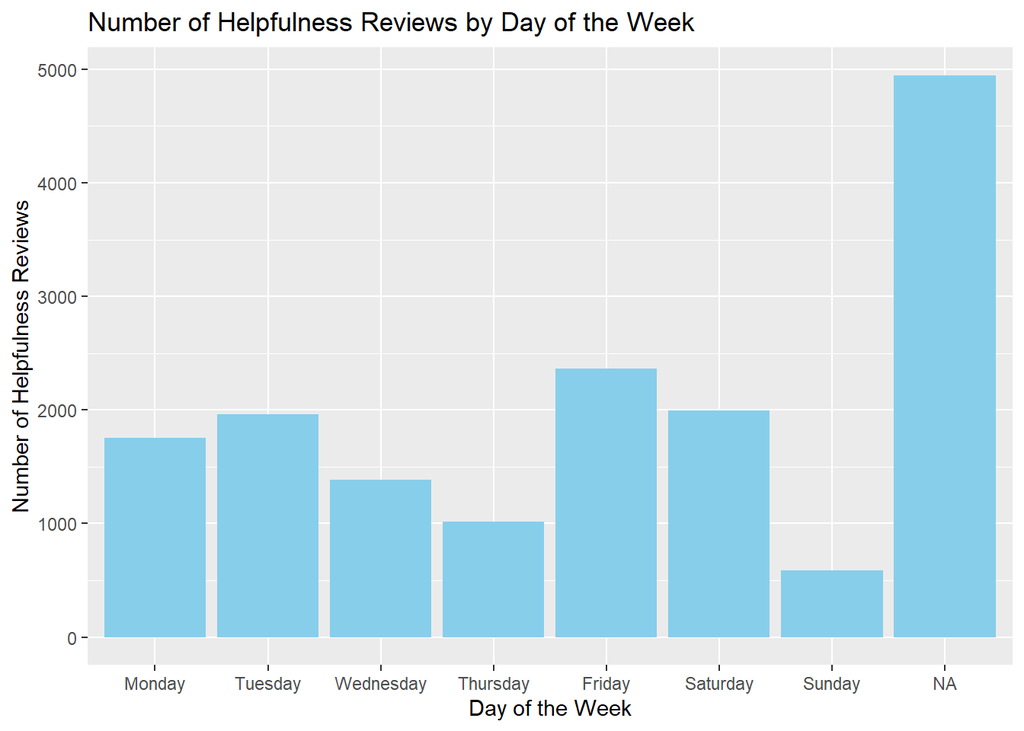

```r
# Bar chart of "Day of the week" and "Reviews.numHelpful"

# Convert the string to a Date object
amazon.df$reviews.date <- as.Date(amazon.df$reviews.date)

# Extract the day of the week
day_of_week <- weekdays(amazon.df$reviews.date)
day_order <- c("Monday", "Tuesday", "Wednesday", "Thursday", "Friday", "Saturday", "Sunday")
day_of_week <- factor(day_of_week, levels = day_order)

# Bar chart
ggplot(amazon.df, aes(x = day_of_week, y = reviews.numHelpful)) +
  geom_bar(stat = "identity", fill = "skyblue") +

  labs(x = "Day of the Week", y = "Number of Helpfulness Reviews", title = "Number of Helpfulness Reviews by Day of the Week")
```

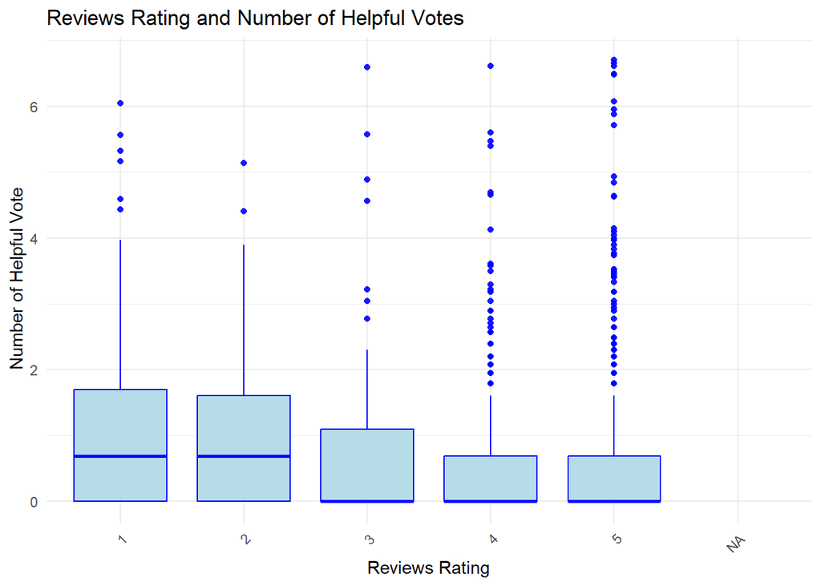

```r
# Box plot of reviews.rating vs reviews.numHelpful
ggplot(amazon.df, aes(x = factor(reviews.rating), y = log(reviews.numHelpful))) +
  geom_boxplot(fill = "lightblue", color = "blue", alpha = 0.9) +
  labs(title = "Reviews Rating and Number of Helpful Votes",
       x = "Reviews Rating",
       y = " Number of Helpful Vote") +
  theme_minimal() +
  theme(axis.text.x = element_text(angle = 45, hjust = 1))
```

### **Cleaning Data**

**Since our dependent variable are “reviews.numHelpful” & “reviews.doRecommend”, we cannot replace the missing values in the column by median or mean. Instead, we will omit any NA’s present**

```r
#Remove missing value for 'reviews.numHelpful'
amazon.df <- amazon.df[!is.na(amazon.df$reviews.numHelpful),]
```

```r
amazon.df$reviews.numHelpful <- ifelse(amazon.df$reviews.numHelpful > 0, 1, 0)
# The proportion of 'Reviews.numHelpful' with all missing values
missing.term<-group_by(amazon.df, amazon.df$reviews.numHelpful)
missing.term<-summarise(missing.term,count=n())
missing.term$count<-as.numeric(missing.term$count)
missing.term<-mutate(missing.term, percent=count/sum(count))
missing.term%>%kable(caption="Table: The proportion of helpful and non-helpful reviews with all missing observations")%>%kableExtra::kable_styling(bootstrap_options = "striped")
```

Table: The proportion of helpful and non-helpful reviews with all missing observations

| amazon.df$reviews.numHelpful | count | percent |
| --- | --- | --- |
| 0 | 22214 | 0.9023845 |
| 1 | 2403 | 0.0976155 |

```r
#The proportion of 'Reviews.numHelpful' without all missing values
amazon.df2<-filter(amazon.df, reviews.doRecommend!="NA", reviews.rating!="NA")
nomissing <-group_by(amazon.df2,reviews.numHelpful)
nomissing<-summarise(nomissing,count=n())
nomissing$count<-as.numeric(nomissing$count)
nomissing<-mutate(nomissing, percent=count/sum(count))
nomissing%>%kable(caption="Table: The proportion of helpful and non-helpful reviews without missing values")%>%kableExtra::kable_styling(bootstrap_options = "striped", full_width = FALSE)
```

Table: The proportion of helpful and non-helpful reviews without missing values

| reviews.numHelpful | count | percent |
| --- | --- | --- |
| 0 | 22213 | 0.9039228 |
| 1 | 2361 | 0.0960772 |

The proportion of “helpful” and “non-helpful” in “reviews.Helpful” in the dataset including all missing values are 9.76% and 90.23% respectively. After removing all missing value, its proportion is 9.6% for “helpful” and 90.39% for “non-helpful” and the dimension of the dataset is 24,574 observations which is large enough to build a predictive model. Therefore, we can remove all missing values without affecting results.

```r
# Remove missing value for 'reviews.doRecommend'
amazon.df <- amazon.df[!is.na(amazon.df$reviews.doRecommend),]
```

```r
#The proportion of 'reviews.doRecommend' without all missing values

nomissing.Re <-group_by(amazon.df,reviews.doRecommend)
nomissing.Re<-summarise(nomissing.Re,count=n())
nomissing.Re$count<-as.numeric(nomissing.Re$count)
nomissing.Re<-mutate(nomissing.Re, percent=count/sum(count))
nomissing.Re%>%kable(caption="Table: The proportion of recommendation and non recommendation reviews without missing values")%>%kableExtra::kable_styling(bootstrap_options = "striped", full_width = FALSE)
```

Table: The proportion of recommendation and non recommendation reviews without missing values

| reviews.doRecommend | count | percent |
| --- | --- | --- |
| FALSE | 1021 | 0.041548 |
| TRUE | 23553 | 0.958452 |

```r
#Replacing missing values in "reviews.rating with mode since it is a categorical variable
amazon.df$reviews.rating <- na_replace(amazon.df$reviews.rating, get_mode(amazon.df$reviews.rating))
```

### **Create new variable(s)**

**Create a new variable “reviews.length**

```r
# covert 'review.text' to character
amazon.df2$reviews.text <- as.character(amazon.df2$reviews.text)

# First, we create a column specifying the length (number of characters) of the review
amazon.df2$reviews.length <- sapply(amazon.df2$reviews.text, function(x) stri_length(stri_trans_nfkd(x)))
```

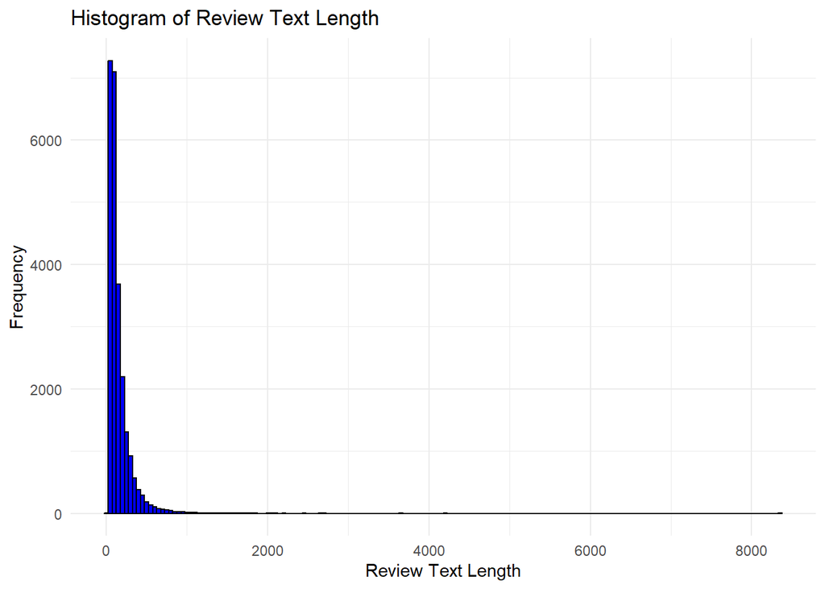

```r
# Create a histogram of the length of review.text
ggplot(amazon.df2, aes(x = reviews.length)) +
  geom_histogram(binwidth = 50, fill = "blue", color = "black") +
  labs(title = "Histogram of Review Text Length",
       x = "Review Text Length",
       y = "Frequency")+
  theme_minimal()
```

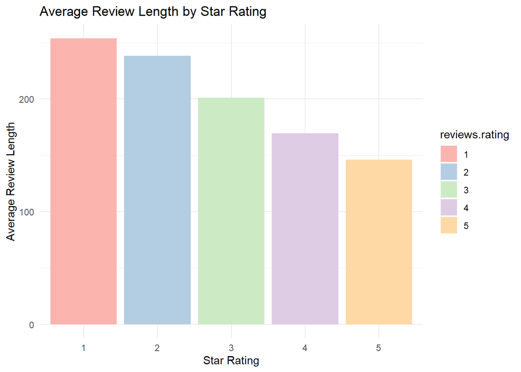

```r
# Bar Chart of Average Text Length and Review Rating
amazon.df2$reviews.rating <- as.factor(amazon.df2$reviews.rating)

# Group by Rating and calculate average review length
avg.length.per.rating <- amazon.df2 %>%
  group_by(reviews.rating) %>%
  summarise(avg.length = mean(reviews.length))

# Create a bar chart
ggplot(avg.length.per.rating, aes(x= reviews.rating, y = avg.length, fill = reviews.rating)) +
  geom_bar(stat = "identity") +
  labs(title = "Average Review Length by Star Rating",
       x = "Star Rating",
       y = "Average Review Length") +
  scale_fill_brewer(palette = "Pastel1") +
  theme_minimal()
```

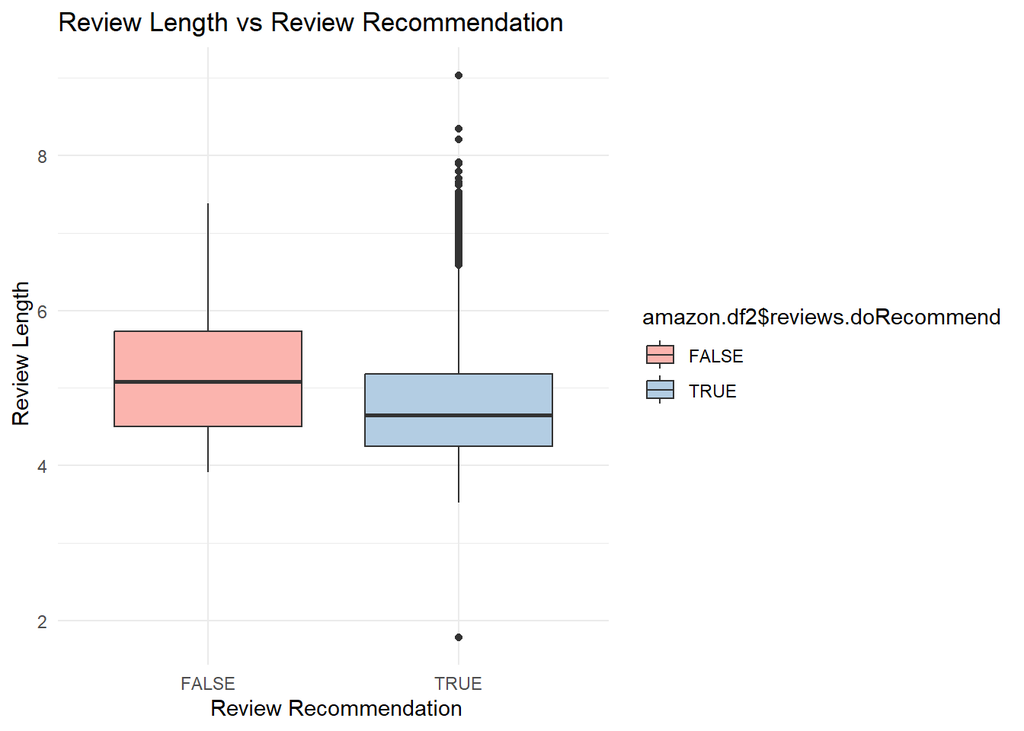

```r
#Box plot between "recommend" and "reviews length"
ggplot(amazon.df2, aes(x = reviews.doRecommend, y = log(reviews.length))) +
  geom_boxplot(aes(fill = amazon.df2$reviews.doRecommend))+
  labs(title = "Review Length vs Review Recommendation",
       x = " Review Recommendation",
       y = " Review Length") +
  scale_fill_brewer(palette = "Pastel1") +
  theme_minimal()
```

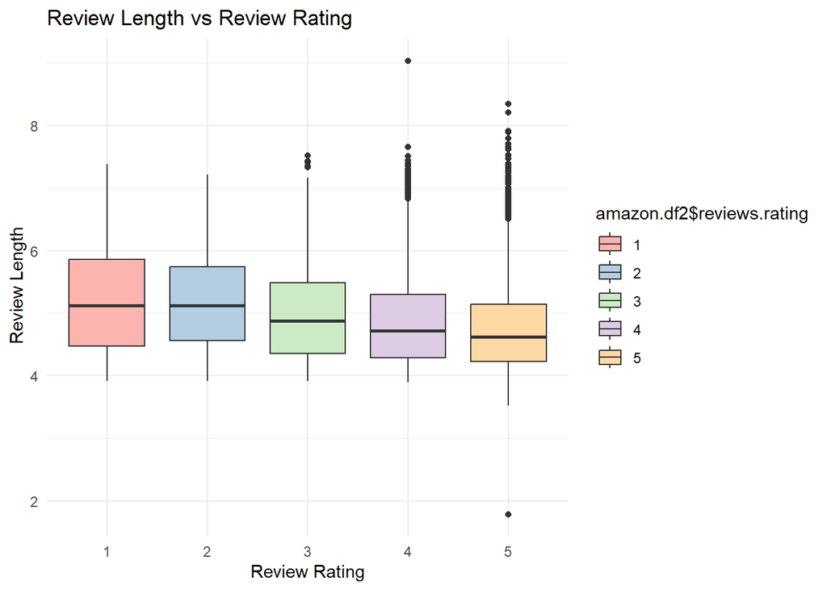

```r
#Box Plot of Review Rating and Review Text Length
amazon.df2$reviews.rating <- as.factor(amazon.df2$reviews.rating)

ggplot(amazon.df2, aes(x = reviews.rating, y = log(reviews.length))) +
  geom_boxplot(aes(fill = amazon.df2$reviews.rating))+
  labs(title = "Review Length vs Review Rating",
       x = "Review Rating",
       y = " Review Length") +
  scale_fill_brewer(palette = "Pastel1") +
  theme_minimal()
```

**Create new variable “day_of_week”**

```r
amazon.df2$day_of_week <- weekdays(amazon.df2$reviews.date)
```

**Create new variable “reviews.numdates”** We would like to know how many times the date when the review was seen.

```r
amazon.df2$reviews.numdates <- sapply(strsplit(amazon.df2$reviews.dateSeen, ","), length)
```

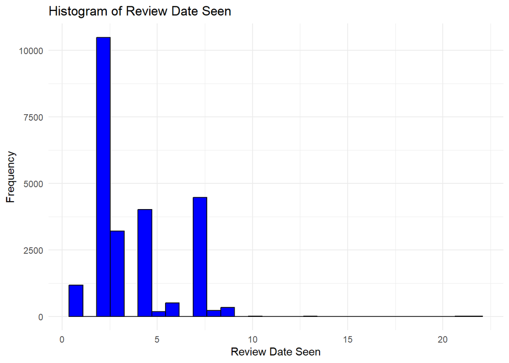

```r
# Create a histogram of the times of review.dateSeen
ggplot(amazon.df2, aes(x = reviews.numdates)) +
  geom_histogram( fill = "blue", color = "black") +
  labs(title = "Histogram of Review Date Seen",
       x = "Review Date Seen",
       y = "Frequency")+
  theme_minimal()
```

**Create new variable “new_categories”**

```r
# Splitting the 'categories' column by commas
separated_categories <- amazon.df2 %>%
 separate_rows(categories, sep = ",") %>%
  # Remove whitespace
  mutate(categories = trimws(categories)) %>%
  # Count occurrences of each category
  group_by(categories) %>%
  summarise(Count = n()) %>%
  arrange(desc(Count))
print(separated_categories)
```

```
## # A tibble: 120 × 2
##    categories           Count
##    <chr>                <int>
##  1 Electronics          30501
##  2 Computers & Tablets  15655
##  3 Tablets              15407
##  4 All Tablets          13266
##  5 iPad & Tablets       12861
##  6 Electronics Features 12207
##  7 Fire Tablets         11751
##  8 Home                 10466
##  9 Amazon Devices        9104
## 10 Featured Brands       9104
## # ℹ 110 more rows
```

```r
amazon.df2 <- amazon.df2 %>%
  mutate(new_categories = case_when(
    grepl("Tablet", categories) ~ "Computer & Tablets",
    grepl("Computer", categories) ~ "Computer & Tablets",
    grepl("Cable", categories) ~ "Electronics",
    grepl("Audio", categories) ~ "Electronics",
     grepl("iPod", categories) ~ "Electronics",
    grepl("Home", categories) ~ "Home",
    grepl("Smart", categories) ~ "Home",
    grepl("Shop", categories) ~ "Home",
    grepl("Kitchen", categories) ~ "Home",
    grepl("Speaker", categories) ~ "Home",
    grepl("Office", categories) ~ "Home",
    grepl("Alarm", categories) ~ "Home",
    grepl("Voice", categories) ~ "Home",
    grepl("Stereo", categories) ~ "Home",
    grepl("Remote", categories) ~ "Home",
    grepl("Surveillance", categories) ~ "Home",
    grepl("Electronic", categories) ~ "Electronics",
    grepl("Cell", categories) ~ "Electronics",
    grepl("Adapter", categories) ~ "Electronics",
    grepl("Mobile", categories) ~ "Electronics",
    grepl("TV", categories) ~ "Entertainment",
    grepl("Movies", categories) ~ "Entertainment",
    grepl("Music", categories) ~ "Entertainment",
    grepl("Streaming", categories) ~ "Entertainment",
    grepl("Game", categories) ~ "Entertainment",
    grepl("Accessories", categories) ~ "Accessories",
    grepl("Reader", categories) ~ "Books",
    grepl("Book", categories) ~ "Books",
    grepl("Kindle", categories) ~ "Books",
    grepl("College", categories) ~ "College & Education",
    grepl("Amazon", categories) ~ "Amazon Devices",
    grepl("Top", categories) ~ "Other",
    grepl("Bag", categories) ~ "Other",
    grepl("Storage", categories) ~ "Other",
    grepl("Wi-Fi", categories) ~ "Other",
    grepl("Walmart", categories) ~ "Other",
    grepl("Brand", categories) ~ "Other",
    grepl("Frys", categories) ~ "Other",
    grepl("Toy", categories) ~ "Other",
    grepl("Clearance", categories) ~ "Other",
    grepl("Kids", categories) ~ "Other",
    grepl("Electrical", categories) ~ "Other",
    TRUE ~ categories
  )) %>%
  group_by(new_categories)
```

We grouped 41 dummy variables into 9 groups: “Electronics”, “Computer & Tablets”, “Home”, “Amazon Devices”, “Books”, “Entertainment”, “Accessories”, “College & Education”, and “Other”.

**Create a new variable “isHelpful” and “doRecommend” as dependent variables for the analysis**

```r
# Create a dummy variable using reviews.numHelpful, which takes value 0 if there is no helpful vote, and 1 if the review is perceived helpful by at least 1
amazon.df2$isHelpful <- ifelse(amazon.df2$reviews.numHelpful > 0, 1, 0)


# Create a dummy variable using reviews.doRecommend, which takes value 0 if reviewers do not recommend, and 1 if the reviewers do recommend
amazon.df2$doRecommend <- ifelse(amazon.df2$reviews.doRecommend > 0, 1, 0)
```

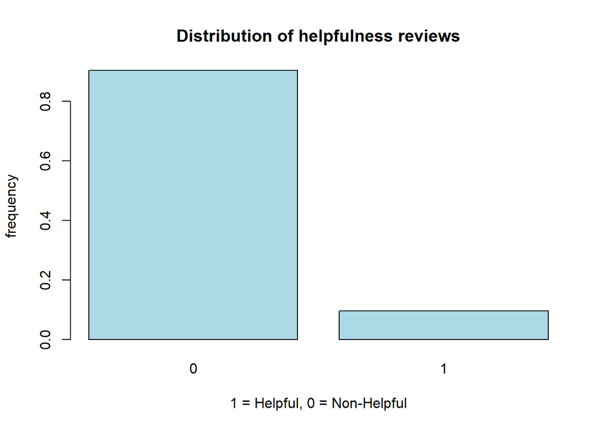

```r
#Distribution of "isHelpful"
barplot(prop.table(table(amazon.df2$isHelpful)), col="lightblue",

      xlab = "1 = Helpful, 0 = Non-Helpful",
        ylab = "frequency",
        main = "Distribution of helpfulness reviews")
```

There is imbalance in the proportion of helpful and non-helpful reviews in our dataset.

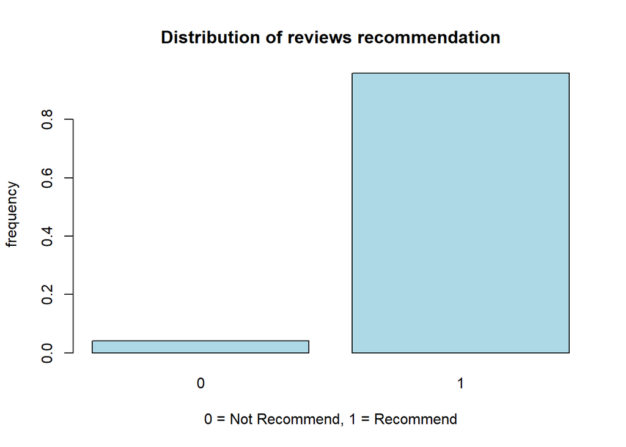

```r
#Distribution of "doRecommend"
barplot(prop.table(table(amazon.df2$doRecommend)), col="lightblue",

      xlab = "0 = Not Recommend, 1 = Recommend",
        ylab = "frequency",
        main = "Distribution of reviews recommendation")
```

There is imbalance in the proportion of recommendation and not recommendation reviews in our dataset.

**Contingency table of “isHelpful” and “reviews.doRecommend”**

```r
CrossTable(amazon.df2$reviews.doRecommend, amazon.df2$isHelpful, prop.c = FALSE, prop.chisq = FALSE, prop.t = FALSE)
```

```
##    Cell Contents
## |-------------------------|
## |                       N |
## |           N / Row Total |
## |-------------------------|
##
## =======================================================
##                                   amazon.df2$isHelpful
## amazon.df2$reviews.doRecommend        0       1   Total
## -------------------------------------------------------
## FALSE                               824     197    1021
##                                   0.807   0.193   0.042
## -------------------------------------------------------
## TRUE                              21389    2164   23553
##                                   0.908   0.092   0.958
## -------------------------------------------------------
## Total                             22213    2361   24574
## =======================================================
```

### **Creating training and validation set with oversampling**

```r
helpful <- amazon.df2[amazon.df2$isHelpful == "1",]
none.helpful <- amazon.df2[amazon.df2$isHelpful == "0",]

# partitioning data
set.seed(2)

# create a variable with values of helpful reviews for training data
train.df.helpful <- helpful[sample(nrow(helpful), 1181),] # 1181 is a half of the total observations of the helpful group

# create a variable with values of non-helpful reviews for training data
train.df.none.helpful <- none.helpful[sample(nrow(none.helpful), 1181),]

# Combining two groups into one training dataset
train.df <- rbind(train.df.helpful, train.df.none.helpful)
```

```r
# create a variable with values of helpful reviews for validation data
valid.df.helpful <- helpful[sample(nrow(helpful), 1181),]

# create a variable with values of non-helpful reviews for validation data
valid.df.none.helpful <- none.helpful[sample(nrow(none.helpful), 11121),]

# Combining two groups into one validation dataset
valid.df <- rbind(valid.df.helpful, valid.df.none.helpful)
```

```r
# Checking again
train.checking<-group_by(train.df, reviews.numHelpful)
train.checking<-summarise(train.checking, count=n())
valid.checking<-group_by(valid.df, reviews.numHelpful)
valid.checking<-summarise(valid.checking, count=n())
valid.checking<-mutate(valid.checking, percent=count/sum(count))
train.checking%>%kable(caption="Table: Checking training set after oversampling")%>%kableExtra::kable_styling(bootstrap_options = "striped")
```

Table: Checking training set after oversampling

| reviews.numHelpful | count |
| --- | --- |
| 0 | 1181 |
| 1 | 1181 |

```r
valid.checking%>%kable(caption = "Table: Checking validation after oversampling")%>%kableExtra::kable_styling(bootstrap_options = "striped")
```

Table: Checking validation after oversampling

| reviews.numHelpful | count | percent |
| --- | --- | --- |
| 0 | 11121 | 0.9039993 |
| 1 | 1181 | 0.0960007 |

### **Building logistic regression model on training dataset**

```r
mod1<-glm(reviews.numHelpful~factor(brand) + factor(day_of_week) + factor(reviews.doRecommend) +  factor(reviews.rating)  + reviews.length + reviews.numdates, data = train.df, family = binomial(link="logit"))
summary(mod1)
```

```
##
## Call:
## glm(formula = reviews.numHelpful ~ factor(brand) + factor(day_of_week) +
##     factor(reviews.doRecommend) + factor(reviews.rating) + reviews.length +
##     reviews.numdates, family = binomial(link = "logit"), data = train.df)
##
## Coefficients:
##                                   Estimate Std. Error z value Pr(>|z|)
## (Intercept)                      1.8534052  0.4406787   4.206 2.60e-05 ***
## factor(brand)Amazon Echo         0.4418866  0.3566308   1.239 0.215324
## factor(brand)Amazon Fire         0.6021547  0.6233215   0.966 0.334023
## factor(brand)Amazon Fire Tv     -0.5976102  0.1441535  -4.146 3.39e-05 ***
## factor(day_of_week)Monday       -0.5263854  0.1467120  -3.588 0.000333 ***
## factor(day_of_week)Saturday      0.2371217  0.1234887   1.920 0.054834 .
## factor(day_of_week)Sunday        0.0529082  0.1674340   0.316 0.752007
## factor(day_of_week)Thursday     -0.3206757  0.1868864  -1.716 0.086183 .
## factor(day_of_week)Tuesday       0.1321895  0.1884122   0.702 0.482930
## factor(day_of_week)Wednesday    -0.6397406  0.1487565  -4.301 1.70e-05 ***
## factor(reviews.doRecommend)TRUE  0.6453384  0.3174015   2.033 0.042033 *
## factor(reviews.rating)2         -0.5623583  0.6362086  -0.884 0.376739
## factor(reviews.rating)3         -2.0434269  0.5012414  -4.077 4.57e-05 ***
## factor(reviews.rating)4         -2.2081107  0.5199273  -4.247 2.17e-05 ***
## factor(reviews.rating)5         -2.3081380  0.5184843  -4.452 8.52e-06 ***
## reviews.length                   0.0032275  0.0003277   9.849  < 2e-16 ***
## reviews.numdates                -0.1953510  0.0241261  -8.097 5.63e-16 ***
## ---
## Signif. codes:  0 '***' 0.001 '**' 0.01 '*' 0.05 '.' 0.1 ' ' 1
##
## (Dispersion parameter for binomial family taken to be 1)
##
##     Null deviance: 3274.4  on 2361  degrees of freedom
## Residual deviance: 2966.5  on 2345  degrees of freedom
## AIC: 3000.5
##
## Number of Fisher Scoring iterations: 5
```

### **Building logistic regression model on unbalancing dataset**

```r
# Using set.seed() to ensure reproducibility
set.seed(1)

# Creating training set (60%)
train.sample <- sample(rownames(amazon.df2), dim(amazon.df2)[1]*0.6)
train.df1 <- amazon.df2[train.sample, ]

# Create validation set (40%)
valid.sample <- setdiff(rownames(amazon.df2), train.sample)
valid.df1 <- amazon.df2[valid.sample, ]
```

```r
mod2<-glm(reviews.numHelpful~factor(brand) + factor(day_of_week) + factor(reviews.doRecommend) + factor(reviews.rating)  + reviews.length + reviews.numdates, data = train.df1, family = binomial(link="logit"))
summary(mod2)
```

```
##
## Call:
## glm(formula = reviews.numHelpful ~ factor(brand) + factor(day_of_week) +
##     factor(reviews.doRecommend) + factor(reviews.rating) + reviews.length +
##     reviews.numdates, family = binomial(link = "logit"), data = train.df1)
##
## Coefficients:
##                                   Estimate Std. Error z value Pr(>|z|)
## (Intercept)                     -0.9395114  0.1820776  -5.160 2.47e-07 ***
## factor(brand)Amazon Echo         0.1684101  0.2346905   0.718 0.473014
## factor(brand)Amazon Fire         0.1359904  0.3614672   0.376 0.706755
## factor(brand)Amazon Fire Tv     -0.4373103  0.0973348  -4.493 7.03e-06 ***
## factor(day_of_week)Monday       -0.3633600  0.0999125  -3.637 0.000276 ***
## factor(day_of_week)Saturday      0.2460067  0.0798453   3.081 0.002063 **
## factor(day_of_week)Sunday        0.3339322  0.1091194   3.060 0.002212 **
## factor(day_of_week)Thursday     -0.1644822  0.1313556  -1.252 0.210501
## factor(day_of_week)Tuesday      -0.0057781  0.1195493  -0.048 0.961452
## factor(day_of_week)Wednesday    -0.4880921  0.1071677  -4.554 5.25e-06 ***
## factor(reviews.doRecommend)TRUE -0.0971596  0.2066428  -0.470 0.638225
## factor(reviews.rating)2         -0.6733439  0.2676496  -2.516 0.011877 *
## factor(reviews.rating)3         -1.5800580  0.2488793  -6.349 2.17e-10 ***
## factor(reviews.rating)4         -1.1674896  0.2576138  -4.532 5.84e-06 ***
## factor(reviews.rating)5         -1.2963256  0.2568630  -5.047 4.49e-07 ***
## reviews.length                   0.0023777  0.0001463  16.254  < 2e-16 ***
## reviews.numdates                -0.1078682  0.0158144  -6.821 9.05e-12 ***
## ---
## Signif. codes:  0 '***' 0.001 '**' 0.01 '*' 0.05 '.' 0.1 ' ' 1
##
## (Dispersion parameter for binomial family taken to be 1)
##
##     Null deviance: 9027.4  on 14743  degrees of freedom
## Residual deviance: 8513.7  on 14727  degrees of freedom
## AIC: 8547.7
##
## Number of Fisher Scoring iterations: 5
```

### **Evaluating model on validation dataset**

**MODEL 1: Using balanced dataset**

```r
# Using training data to predict the probability in validation dataset
mod1.pred<-predict(mod1, valid.df, type = "response")
```

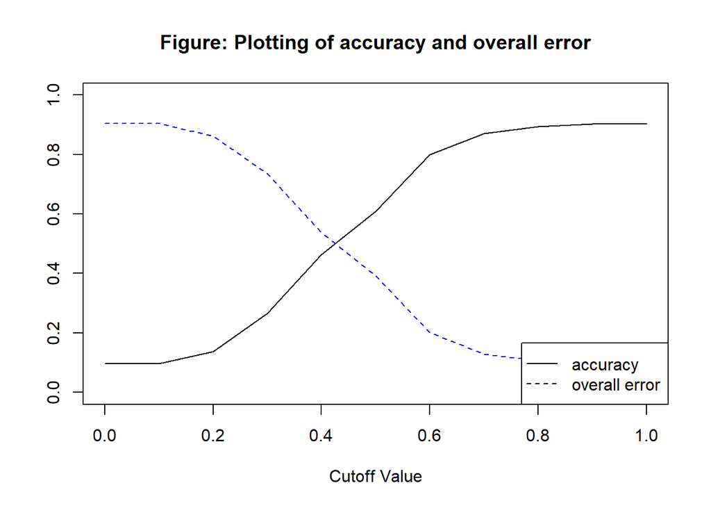

```r
# Using cutoff figure to select the best cutoff value
accT = c()
for (cut in seq(0,1,0.1)){
  cm <- confusionMatrix(factor(ifelse(mod1.pred> cut,1,0)), factor(valid.df$isHelpful))
  accT = c(accT, cm$overall[1])
}
plot(accT ~ seq(0,1,0.1),main="Figure: Plotting of accuracy and overall error", xlab = "Cutoff Value", ylab = "", type = "l", ylim = c(0, 1))
lines(1-accT ~ seq(0,1,0.1), type = "l", lty = 2, col="blue")
legend("bottomright", c("accuracy", "overall error"), lty = c(1, 2), merge = TRUE)
```

```r
# Confusion matrix with cutoff value of 0.85
mod1.conf<-confusionMatrix(factor(ifelse(mod1.pred >0.85,1,0)), factor(valid.df$isHelpful))
mod1.conf$table%>%kable(caption="Table: Confusion matrix of model 1 at cutoff value 0.85")%>%kableExtra::kable_styling(bootstrap_options = "striped")
```

Table: Confusion matrix of model 1 at cutoff value 0.85

|  | 0 | 1 |
| --- | --- | --- |
| 0 | 10954 | 1069 |
| 1 | 167 | 112 |

```r
# The accuracy rate
mod1.conf$overall[1]
```

```
##  Accuracy
## 0.8995285
```

**MODEL 2: Using the unbalanced dataset**

```r
# Using training data to predict probability in validation dataset
mod2.pred<-predict(mod2, valid.df1, type="response")
```

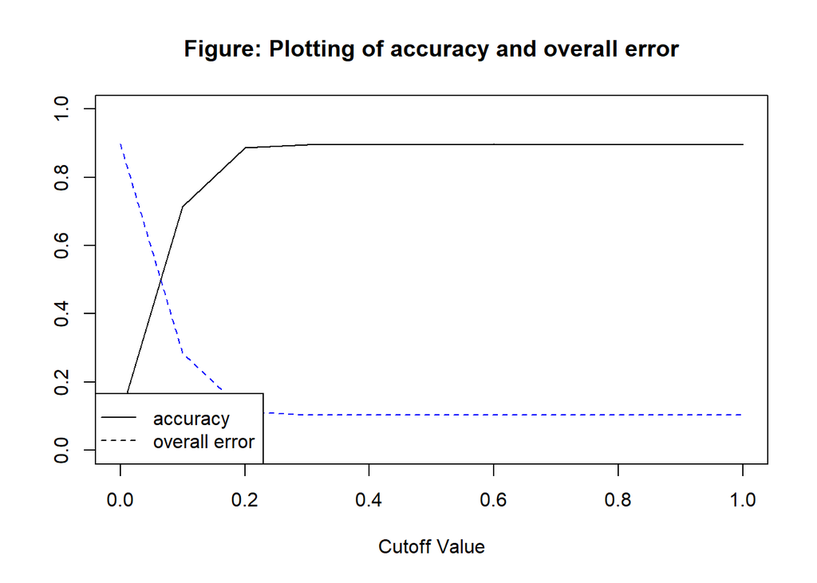

```r
# Using cutoff figure to select the best cutoff value
accT2 = c()
for (cut in seq(0,1,0.1)){
cm <- confusionMatrix(factor(ifelse(mod2.pred> cut,1,0)), factor(valid.df1$isHelpful))
accT2 = c(accT2, cm$overall[1])
}
plot(accT2 ~ seq(0,1,0.1),main="Figure: Plotting of accuracy and overall error", xlab = "Cutoff Value", ylab = "", type = "l", ylim = c(0, 1))
lines(1-accT2 ~ seq(0,1,0.1), type = "l", lty = 2, col="blue")
legend("bottomleft", c("accuracy", "overall error"), lty = c(1, 2), merge = TRUE)
```

```r
# Confusion matrix with cutoff value of 0.85
mod2.conf<-confusionMatrix(factor(ifelse(mod2.pred >0.85,1,0)), factor(valid.df1$isHelpful))
mod2.conf$table%>%kable(caption="Table: Confusion matrix of model 1 at cutoff value 0.85")%>%kableExtra::kable_styling(bootstrap_options = "striped")
```

|  | 0 | 1 |
| --- | --- | --- |
| 0 | 8810 | 1009 |
| 1 | 9 | 2 |

```r
# The accuray rate
mod2.conf$overall[1]
```

```
##  Accuracy
## 0.8964395
```

**Comparison and Choose The Best Model**

```r
model<-c("Model1","Model2")

accuracy<-c(mod1.conf$overall[1],mod2.conf$overall[1])
sensitivity<-c(mod1.conf$byClass[1],mod2.conf$byClass[1])

table<-data.frame(model,accuracy,sensitivity)

kable(table, caption = "Accuracy measuring of predictive models") %>%
  kable_styling(full_width = T)
```

Accuracy measuring of predictive models

| model | accuracy | sensitivity |
| --- | --- | --- |
| Model1 | 0.8995285 | 0.9849834 |
| Model2 | 0.8964395 | 0.9989795 |

### **Naive Bayes Classifier for Categorical Predictors**

```r
# Creating Naivee Bayes dataset
naive.df<-amazon.df2[,c(5,16,23,24,25,27,28)]

# Creating bin and Changing numerical variables to factor
naive.df$isHelpful<-factor(naive.df$isHelpful)
naive.df$doRecommend<-factor(round(naive.df$doRecommend))
naive.df$reviews.length<-factor(round(naive.df$reviews.length))
naive.df$reviews.numdates<-factor(round(naive.df$reviews.numdates))
naive.df$reviews.rating<-factor(naive.df$reviews.rating)

# Partitioning data into 60% training data and 40% validation data
set.seed(3)
train.naive.index<-sample(row.names(naive.df), 0.6*dim(naive.df)[1])
valid.naive.index<-setdiff(row.names(naive.df), train.naive.index)
train.naive<-naive.df[train.naive.index,]
valid.naive<-naive.df[valid.naive.index,]
```

```r
#Running Naive Bayes
isHelpful.naive<-naiveBayes(isHelpful~., data=train.naive)
isHelpful.naive
```

[output not shown]

[output cut: 702 more lines]

```
##   0 0.0515688335 0.4119501576 0.1281339138 0.1688184957 0.0072811890
##   1 0.0232067511 0.5513361463 0.1526019691 0.1026722925 0.0063291139
##    reviews.numdates
## Y              6            7            8            9           10
##   0 0.0161387179 0.1919381474 0.0080318271 0.0160636541 0.0000750638
##   1 0.0569620253 0.0780590717 0.0175808720 0.0112517581 0.0000000000
##    reviews.numdates
## Y             13           21           22
##   0 0.0000000000 0.0000000000 0.0000000000
##   1 0.0000000000 0.0000000000 0.0000000000
##
##    doRecommend
## Y            0          1
##   0 0.03723165 0.96276835
##   1 0.08087201 0.91912799
```

```r
# Predicting probabilities
pred.naive.prob<-predict(isHelpful.naive, newdata = valid.naive, type="raw")
# Predicting class membership
pred.naive.class<-predict(isHelpful.naive, newdata = valid.naive)
```

```r
#Evaluating Naive Bayes model by confusion matrix
confusionMatrix(factor(pred.naive.class), factor(valid.naive$isHelpful))
```

```
## Confusion Matrix and Statistics
##
##           Reference
## Prediction    0    1
##          0 8755  866
##          1  136   73
##
##                Accuracy : 0.8981
##                  95% CI : (0.8919, 0.904)
##     No Information Rate : 0.9045
##     P-Value [Acc > NIR] : 0.9847
##
##                   Kappa : 0.0957
##
##  Mcnemar's Test P-Value : <2e-16
##
##             Sensitivity : 0.98470
##             Specificity : 0.07774
##          Pos Pred Value : 0.90999
##          Neg Pred Value : 0.34928
##              Prevalence : 0.90448
##          Detection Rate : 0.89064
##    Detection Prevalence : 0.97874
##       Balanced Accuracy : 0.53122
##
##        'Positive' Class : 0
##
```

### **Decile-Wise Lift Chart**

**Lift Chart**

```r
gain<-gains(valid.df$isHelpful, mod1.pred, groups = length(mod1.pred))
```

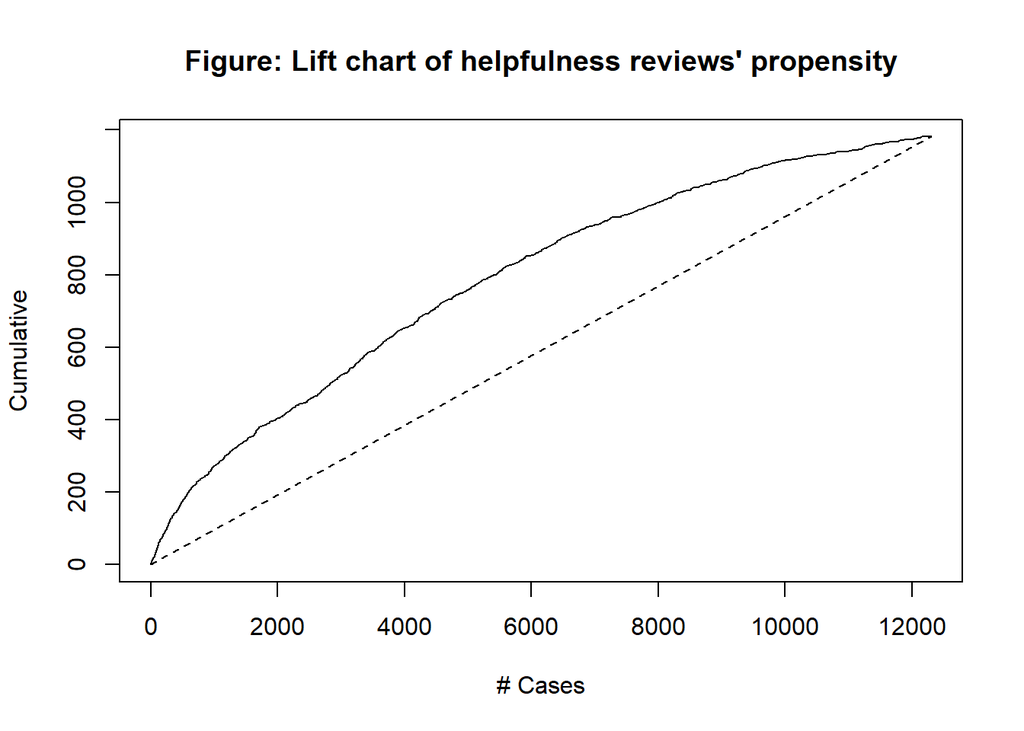

```r
plot(c(0,gain$cume.pct.of.total*sum(valid.df$isHelpful))~c(0, gain$cume.obs), xlab="# Cases", ylab="Cumulative", main = "Figure: Lift chart of helpfulness reviews' propensity", type="l")
lines(c(0,sum(valid.df$isHelpful))~c(0,dim(valid.df)[1]), lty=2)
```

**Decile Chart**

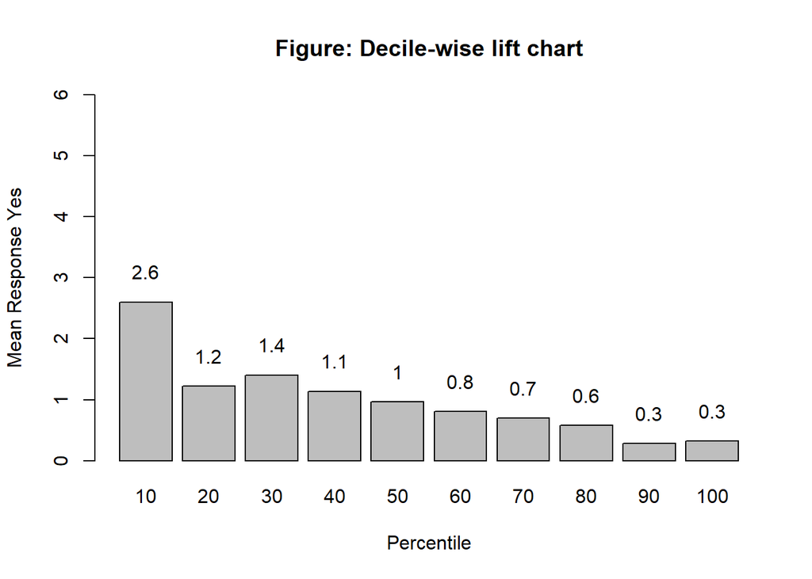

```r
decile.data<-data.frame("actual" = valid.df$isHelpful, "probability" = mod1.pred)
gain.mod1<-gains(decile.data$actual, decile.data$probability)
midpoints.mod1 <-barplot(gain.mod1$mean.resp/mean(decile.data$actual), names.arg= gain.mod1$depth, ylim = c(0,6),
xlab = "Percentile", ylab = "Mean Response Yes", main = "Figure: Decile-wise lift chart")
text(midpoints.mod1, gain.mod1$mean.resp/mean(decile.data$actual)+0.5, labels=round(gain.mod1$mean.resp/mean(decile.data$actual), 1), cex = 1)
```